[figure not shown]

# **IA 717: CHAI & fairness: linguistics of AI ethics charters & manifestos**

### Project Supervisor

Maria Boritchev maria.boritchev@telecom-paris.fr

### Project student

Josephine Bernard josephine.bernard@telecom-paris.fr  
Laury Magne laury.magne@telecom-paris.fr  
Dan Hayoun dan.hayoun@telecom-paris.fr  
Nicolas Allègre nicolas.allegre@telecom-paris.fr

Year 2024-2025

# **Context and objectives**

> The recent years have seen a surge of initiatives with the goal of defining what “ethical” artificial intelligence would or should entail, resulting in the publication of various charters and manifestos discussing AI ethics; these documents originate from academia, AI industry companies, non-profits, regulatory institutions, and the civil society. The contents of such documents vary wildly, from short, vague position statements to verbatims of democratic debates or impact assessment studies. As such, they are a marker of the social world of artificial intelligence, outlining the tenets of different actors, the consensus and dissensus on important goals, and so on. [Mapping AI Ethics: a meso-scale analysis of its charters and manifestos, M. Gornet et al, 2024.](https://mapaie.telecom-paris.fr/mapaie-paper.pdf)

The objective of this project to study the linguistic specificities of a corpus of charters and manifestos of AI ethics, called `MapAIE`. We will study the semantic structure of sentences from MapAIE using the Abstract Meaning Representation ([AMR](https://github.com/amrisi/amr-guidelines/blob/master/amr.md)) abstraction method. In particular, we will focus on the usage and the environment of the word *fairness*, in order to see its context and the (possibly different?) meanings associated with its usage.

### Evaluation

The project is evaluated through a presentation with a report and your completed project. Grades will be partly individual and partly collective.

- Top, Context and objectives
- Chapter 0 initialisation Python
- Chapter 1 - Général
- Chapter 2 - Analyse et comparaison 3 corpus
  - Section 2.1 - analyse globale
  - Section 2.2 - analyse mot fairness
- Chapter 3 - Corpus élargie sur TXT
  - Section 3.1 analyse globale
  - Section 3.2 analyse sur fairness
  - Section 3.3 analyse n-gram de fairness
  - Section 3.4 analyse POS-tag de fairness
  - Section 3.5 analyse des voisins (Justice & Bias)

# **0 - Code Python initial**

### 0.1) Première partie imports et fonctions globales

```python
# python -m pip install matplotlib numpy scipy sklearn tabulate
# !pip install Unidecode wordcloud spacy
# !python -m spacy download en_core_web_sm

# Global import
import itertools
import math
import os
import re
import shutil
import string
import typing
from collections import defaultdict
from collections.abc import Iterable
from itertools import islice
from pathlib import Path
from pprint import pprint

import matplotlib.pyplot as plt
import numpy as np
import numpy.typing as npt
import spacy
from scipy.stats import norm  # type: ignore[import-untyped]
from sklearn.feature_extraction.text import CountVectorizer
from tabulate import tabulate
from unidecode import unidecode
from wordcloud import WordCloud

from Corpus import Corpus

EXEC_PYTHON_IS_NOT_EXIST = False  # Execute action of git repo (dll, parse, prepro, corpus)
EXEC_MAPAIE_DLL = False
EXEC_MAPAIE_PARSE = False
EXEC_MAPAIE_LANG = False
EXEC_MAPAIE_PREPRO = True
EXEC_MAPAIE_CORPUS = True
PATH_DATA_FOLDER = '../data'
PATH_LOG_FOLDER = '../log'
PATH_DATA_TXT = '../data/txts'
PATH_DATA_DOCS = '../data/docs'
PATH_DATA_PREPROCESSED = '../data/preprocessed'
PATH_DATA_CORTEX = '../data/corpus_cortext'
PATH_DATA_IRAMUTEQ = '../data/corpus_iramuteq'
FILENAME_DATA_IRAMUTEQ = 'corpus.txt'
FILENAME_DATA_LANG = 'corpus_lang.csv'
FILENAME_DATA_LANG_PREPRO = 'corpus_lang_preprocessing.csv'
PATH_DATA_FILE_LANG = os.path.join(PATH_DATA_FOLDER, FILENAME_DATA_LANG)
PATH_DATA_FILE_IRAMUTEQ = os.path.join(PATH_DATA_IRAMUTEQ, FILENAME_DATA_IRAMUTEQ)
TYPE_METHOD = ['cortex', 'iramuteq', 'txt']
CHARSET = 'UTF-8'

def take(n: int, iterable: Iterable) -> list[any]:
    """Return the first n items of the iterable as a list."""
    return list(islice(iterable, n))
#end def take

def dict_revert(x: dict[str, any], sort: bool=False) -> list[list[str, any]]:
    tmp = x
    if sorted is True:
        tmp = dict(sorted(x.items(), key=lambda item: item[1], reverse=True))

    return [[list(x.keys())[i], list(x.values())[i]] for i in range(len(x))]


def preparation_data(exec_actions: dict[str, bool] | bool, force: bool = False):
    """Vérifie la présence des documents et exécute les actions associées.

    :param dict[str, bool] | bool exec_actions: liste des actions à faire
        exec_actions = bool : alors si True => exec_actions['all]=True
        'all' = toutes les actions :
        'dll' = mapaie-1 : télécharge les documents (dl_docs.py) dans data/docs
        'parse' = mapaie-2 : parse les PDF et HTML vers des TXT (parse_docs.py) dans data/txts
        'prepro' = mapaie-3 : exécute les étape NLP de pré-process (preprocess.py) sur les TXT dans data/preprocessed
        'lang' = mapaie-3bis : trouve la langue sur les TXT (create_corpus_before_lang.py)
        'corpus' = mapaie-4 : crée les corpus avec les algo (Iramuteq et Cortex)
    :param bool force: force l'exécution de l'action même si les données existes.
    """
    if type(exec_actions) != dict:
        if exec_actions is True:
            exec_actions = {}
            exec_actions['all'] = True
        else:
            exec_actions = {}

    if exec_actions.get('all') is True:
        exec_actions['dll'] = True
        exec_actions['parse'] = True
        exec_actions['prepro'] = True
        exec_actions['lang'] = True
        exec_actions['corpus'] = True

    if exec_actions.get('corpus') is True:
        if not os.path.exists(PATH_DATA_CORTEX) or not os.path.exists(PATH_DATA_IRAMUTEQ):
            exec_actions['prepro'] = True
    if exec_actions.get('prepro') is True and not os.path.exists(PATH_DATA_PREPROCESSED):
        exec_actions['parse'] = True
    if exec_actions.get('lang') is True and not os.path.exists(PATH_DATA_TXT):
        exec_actions['parse'] = True
    if exec_actions.get('parse') is True and not os.path.exists(PATH_DATA_TXT):
        exec_actions['dll'] = True

    # Actions :
    print(exec_actions)
    actions = ['dll', 'parse', 'prepro', 'lang', 'corpus']
    actions_path = {'dll': PATH_DATA_DOCS, 'parse': PATH_DATA_TXT, 'prepro': PATH_DATA_PREPROCESSED, 'lang': PATH_DATA_TXT, 'corpus': [PATH_DATA_IRAMUTEQ, PATH_DATA_CORTEX]}
    exec_python = {'dll': 'dl_docs.py', 'parse': 'parse_docs.py', 'prepro': 'preproccess.py', 'lang': 'create_corpus_before_lang.py', 'corpus': 'create_corpus.py'}
    for action in actions:
        if exec_actions.get(action) is True:
            print(f'Action à faire pour {action}')
            folders = []
            if type(actions_path[action]) == list:
                folders = actions_path[action]
            else:
                folders = [actions_path[action]]
            if force is True:
                if action =='lang':
                    # os.remove(PATH_DATA_FILE_LANG)
                    print(f'\tRemove fichier {PATH_DATA_FILE_LANG}')
                else:
                    for folder in folders:
                        print(f'\tRemove folder {folder}')
                        # shutil.rmtree(folder)
                        pass

            to_do = False
            for folder in folders:
                to_do = to_do or not os.path.exists(folder)
            if to_do:
                print(f'\tAction : {exec_python[action]}')
                # python dl_docs.py
                # python parse_docs.py
                # python preproccess.py
                # python create_corpus_before_lang.py
                # python create_corpus.py -t themes.json -d data/preprocessed/ -m iramuteq
                # python create_corpus.py -t themes.json -d data/preprocessed/ -m cortext
                # import dl_docs  # ??
                pass
```

```python
liste_actions = {'dll': EXEC_MAPAIE_DLL, 'parse': EXEC_MAPAIE_PARSE, 'prepro': EXEC_MAPAIE_PREPRO, 'lang': EXEC_MAPAIE_LANG, 'corpus': EXEC_MAPAIE_CORPUS}
if EXEC_PYTHON_IS_NOT_EXIST:
    preparation_data(liste_actions)

# CORTEX n'est absolument pas optimisé !!! => Il copie les TXT x fois dans les catégories !
#   =>ça prends beaucoup trop de place et ce n'est pas scalable.
#   =>il faut générer une liste de document pour chaque tag et ce référer soit au dossier TXT,
#   soit n'avoir les documents en un seul exemplaire.
```

### 0.2) Deuxième partie chargement des données

`Corpus` : Classe unique permettant de charger et de manipuler le corpus des données de manière uniforme.

Dans la suite du notebook la variable `list_corpus` contient les types de corpus :

- cortex
- iramuteq
- txt

*Utilisation* :

```
list_corpus['txt'].get_tags()
# >>> set()
list_corpus['cortex'].get_tags()
# >>> {'Trust', 'Solidarity', 'Responsibility', 'Transparency', 'Beneficence', 'Dignity', 'Privacy', 'Non-maleficence', 'Freedom and autonomy', 'Justice and fairness', 'Sustainable'}
list_corpus['iramuteq'].get_tags()
# >>> {'Trust', 'Solidarity', 'Responsibility', 'mapaie', 'Transparency', 'Beneficence', 'Dignity', 'Privacy', 'Non-maleficence', 'Freedom and autonomy', 'Justice and fairness', 'Sustainable'}
```

```python
# Chargement de tout les corpus
list_corpus = {method: Corpus(method) for method in TYPE_METHOD}

# Exemple :
# >>> list_corpus['txt'].get_tags()
# set()
# >>> list_corpus['cortex'].get_tags()
# {'Trust', 'Solidarity', 'Responsibility', 'Transparency', 'Beneficence', 'Dignity', 'Privacy', 'Non-maleficence', 'Freedom and autonomy', 'Justice and fairness', 'Sustainable'}
# >>> list_corpus['iramuteq'].get_tags()
# {'Trust', 'Solidarity', 'Responsibility', 'mapaie', 'Transparency', 'Beneficence', 'Dignity', 'Privacy', 'Non-maleficence', 'Freedom and autonomy', 'Justice and fairness', 'Sustainable'}
```

# **1 - Général**

Our main corpus is called *MapAIE - Mapping AI Ethics*. It is a collection of 436 common charters and manifestos around artificial intelligence and AI ethics. The corpus' [datasheet](https://mapaie.telecom-paris.fr/mapaie-datasheet.pdf) provides detailed information about the collection process and the contents of the corpus.

### 1.1 QUESTION 1.1

1.1 Question: Using the git repository https://gitlab.telecom-paris.fr/tiphaine.viard/mapaie, build the data locally. How many documents are there in the `./pdf` folder? in the `./txt` folder?

1.1 Answer:

- Il n'y a pas de dossier `pdf` mais un dossier `docs`contenant la récupération d'Internet des documents au format HTML ou PDF.
- Le dossier `txts` correspond aux documents ayant été parsés en texte brut.
- Le dossier `preprocessed` correspond aux textes après avoir subit une étape de NLP de découpage en token.
- Les dossiers `corpus_*` correspondent aux résultats de création de corpus textuel par les algorithme IRAMUTEQ et CORTEX.

Différents méthodes de comptage existent, soit par Python soit le plus simple via un simple `ls | wc -l` (Linux) :

```
(Get-ChildItem docs |Measure-Object).count
#    =>629
(Get-ChildItem docs\*.pdf |Measure-Object).count
#    =>307
(Get-ChildItem docs\*.html |Measure-Object).count
#    =>321
(Get-ChildItem txts |Measure-Object).count
#    =>625
```

```python
list_dir = os.listdir(PATH_DATA_DOCS)
print("Nombre de document téléchargé (./docs) : ", len(list_dir))
print("\tNombre de HTML téléchargé (./docs) : ", len([x for x in list_dir if '.html' in x]))
print("\tNombre de PDF téléchargé (./docs) : ", len([x for x in list_dir if '.pdf' in x]))
print("Nombre de document parsé (./txts/) : ", len(os.listdir(PATH_DATA_TXT)))
```

```
Nombre de document téléchargé (./docs) :  624
	Nombre de HTML téléchargé (./docs) :  318
	Nombre de PDF téléchargé (./docs) :  306
Nombre de document parsé (./txts/) :  620
```

### 1.2 QUESTION 1.2

Let's explore the data. As you can see, documents in `./pdf` folder and documents in the `./txt` folder are the same, and the name formatting is such that `n.txt` contains plain text extracted from `n.pdf`.

1.2 Question: Why is it useful to have the data both in .pdf and .txt format? Cite one advantage and one drawback for linguistic analysis for each of the formats.

1.2 Answer:

**PDF/HTML :**

- *D'un part, une grande partie non négligeable des documents scientifiques sont publiés en PDF. Mais des articles sont plus sur des sites web. D'où la nécessité de récupérer ces deux formats.*
- L'avantage, c'est que ces format, PDF et HTML, permettent de garder la mise en forme et les metadata (chapitre, indentation, etc)
- Leur inconvénient, c'est qu'ils sont difficiles à parser, les retours à la ligne ne sont pas ou mal détectés.

**TXT :**

- L'avantage c'est qu'ils sont bien plus faciles à parser/utiliser car les mots sont directement accéssible.
- L'inconvénient c'est la perte d'information lors de l'état de *parsing*. Il n'y plus de mise en forme ou de structure.

### 1.4 QUESTION 1.4

The following presents a non exhaustive list of keywords frequently enocountered in documents and discourse related to AI and ethics of AI:

- fairness;
- algorithmic fairness;
- bias;
- gdpr;
- discrimination;
- biometric;
- regulation;
- artificial general intelligence.

1.4 Question: among these keywords, which ones are the most frequent? Please provide visualizations and comment these visualisations.

1.4 Answer:

Différents méthodes de comptage existent, soit par Python soit le plus simple via un simple `cat |find | wc -w` (Linux) :

```
$list=('fairness', 'algorithmic fairness', 'bias', 'gdpr', 'discrimination', 'biometric', 'regulation', 'artificial general intelligence')
$list | %{ $tmp=(Get-Content .\data\txts\*.txt | Select-String -Pattern $_ -AllMatches).Matches.count;$a=$_+' : '+$tmp;$a }
# fairness : 3059
# algorithmic fairness : 72
# bias : 7753
# gdpr : 2793
# discrimination : 4037
# biometric : 2261
# regulation : 7378
# artificial general intelligence : 95
```

# **2 - Analyse sur les 3 corpus**

## **2.1 - Data Presentation and Retrieval (multi)**

We now want to know more about words and key-words used throughout the corpus. There are several terms that are widely used when writing about ethics of AI, and it is interesting from a linguistic point of view to see where and how these words occur.

### 1.3 QUESTION 1.3

1.3 Question: what are the most frequent words, excluding stopwords, in the whole corpus? Please provide visualizations and comment these visualisations.

```
*** MODEL : cortex
cortex : Taille corpus = 30012540
cortex : Mot le plus utilisé : data = 47499
cortex : Nb initial mot : 116180, Nb mot >1 lettre et stopword : 62737

*** MODEL : iramuteq
iramuteq : Taille corpus = 40105251
iramuteq : Mot le plus utilisé : data = 60534
iramuteq : Nb initial mot : 154432, Nb mot >1 lettre et stopword : 81494

*** MODEL : txt
txt : Taille corpus = 65113631
txt : Mot le plus utilisé : the = 355298
txt : Nb initial mot : 473509, Nb mot >1 lettre et stopword : 199792
```

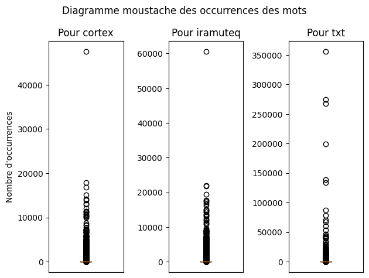

```python
# data = list_corpus['txt']
info_model = {}
plt.close('all')
fig = plt.figure()
fig.suptitle('Diagramme moustache des occurrences des mots')
for i, method in enumerate(list_corpus):
    info_model[method] = {}
    data = list_corpus[method]
    model = data.type_model
    corpus = data.get_corpus()
    print(f"\n*** MODEL : {model}")
    print(f"{data.type_model} : Taille corpus = {len(corpus)}")

    # Sortir tous les tokens
    tokens = {}
    for word in corpus.split():
        if tokens.get(word) == None:
            tokens[word] = 0
        tokens[word] += 1

    # Supprimer tous les mots à 1
    copy = tokens.copy()
    for word in copy :
        if tokens[word] == 1:
            tokens.pop(word, None)

    # Supprimer tous les stopwords
    # On ne le fait pas pour ressortir plus d'information de comparaison entre les 3 corpus

    # Sortir le mot le plus utilisé
    cle_max = max(tokens, key=tokens.get)
    print(f"{data.type_model} : Mot le plus utilisé : {cle_max} = {tokens[cle_max]}")
    print(f"{data.type_model} : Nb initial mot : {len(copy)}, Nb mot >1 lettre et stopword : {len(tokens)}")

    # Extraire les occurrences et les mots
    occurrences_values = list(tokens.values())
    mots = list(tokens.keys())

    # Créer le diagramme en boîte (boxplot)
    ax = fig.add_subplot(1, len(list_corpus), i +1)
    ax.boxplot(occurrences_values)
    ax.set_title(f"Pour {model}")
    if i == 0:
        ax.set_ylabel("Nombre d'occurrences")
    ax.get_xaxis().set_visible(False)

    tokens = dict(sorted(tokens.items(), key=lambda item: item[1], reverse=True))
    info_model[method]['tokens'] = tokens

fig.tight_layout()
plt.show()
```

```python
NB_TOP = 10
top_x = {}
for model in list_corpus:
    tokens = info_model[model]['tokens']
    top_x[model] = {word: tokens[word] for word in take(NB_TOP, tokens)}

# pprint(top_x, sort_dicts=False)

headers = ['cortex', 'cortex', 'iramuteq', 'iramuteq', 'txt', 'txt']
tmp = []
for model in list_corpus:
    data_tmp = top_x[model]
    tmp.append(list(data_tmp.keys()))
    tmp.append(list(data_tmp.values()))

print(tabulate(np.array(tmp).T, headers=headers, tablefmt='pipe'))
```

```
| cortex       |   cortex | iramuteq     |   iramuteq | txt   |    txt |
|:-------------|---------:|:-------------|-----------:|:------|-------:|
| data         |    47499 | data         |      60534 | the   | 355298 |
| systems      |    17878 | systems      |      21949 | and   | 274848 |
| use          |    16875 | use          |      21791 | of    | 267744 |
| intelligence |    15079 | intelligence |      19373 | to    | 198824 |
| also         |    14170 | also         |      17698 | in    | 138304 |
| public       |    13926 | human        |      17608 | a     | 133383 |
| system       |    13097 | public       |      17303 | for   |  87271 |
| human        |    12998 | system       |      16635 | AI    |  78249 |
| artificial   |    12003 | artificial   |      16222 | is    |  70804 |
| research     |    11421 | des          |      15060 | that  |  67586 |
```

```python
stats_info = {}
for model in list_corpus:
    tokens = info_model[model]['tokens']

    occurrences_values = list(tokens.values())
    mediane = np.median(occurrences_values)
    moyenne = np.mean(occurrences_values)
    ecart_type = np.std(occurrences_values)
    Q3 = np.percentile(occurrences_values,90)

    stats_info[model] = {'mediane': mediane, 'moyenne': moyenne, 'sig': ecart_type, 'Q3': Q3}

# pprint(stats_info, sort_dicts=False)
headers=list(stats_info[list(stats_info.keys())[0]].keys())
print(tabulate(stats_info.values(), showindex=list(stats_info.keys()), headers='keys', tablefmt='pipe'))
```

```
|          |   mediane |   moyenne |      sig |   Q3 |
|:---------|----------:|----------:|---------:|-----:|
| cortex   |         5 |   56.8662 |  404.194 |   61 |
| iramuteq |         4 |   58.7168 |  462.474 |   55 |
| txt      |         3 |   44.9017 | 1457.88  |   29 |
```

1.3 Answer:

On remarque que le mot data est bien plus utilisé que tous les autres. Une quinzaine d'autres points surélevés apparaissent.

Nous remarquons aussi, que la fréquence d'apparition des mots sont similaires quelques soit la méthode si les stop-word sont retiré. Ainsi, pour ces mots fréquents le pre-processing n'impacte pas le classement (ils ne sont pas retiré du corpus).

### 1.4 QUESTION 1.4

The following presents a non exhaustive list of keywords frequently enocountered in documents and discourse related to AI and ethics of AI:

- fairness;
- algorithmic fairness;
- bias;
- gdpr;
- discrimination;
- biometric;
- regulation;
- artificial general intelligence.

1.4 Question: among these keywords, which ones are the most frequent? Please provide visualizations and comment these visualisations.

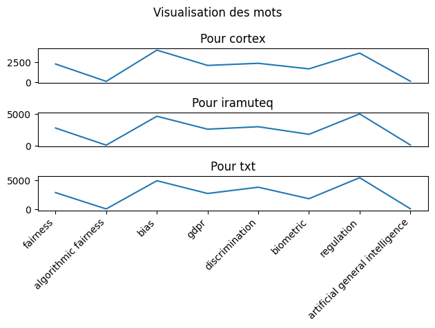

```python
list_word = ['fairness','algorithmic fairness','bias','gdpr','discrimination','biometric','regulation','artificial general intelligence']

ngram_freqs = {}
plt.close('all')
fig = plt.figure()
fig.suptitle('Visualisation des mots')
for i, method in enumerate(list_corpus):
    data = list_corpus[method]
    model = data.type_model
    corpus = list(data.data.values())

    # Faire les 1-3-gram
    vectorizer = CountVectorizer(ngram_range=(1, 3), min_df=3)
    X = vectorizer.fit_transform(corpus)  # Ajuster le vectorizer au corpus
    vocab = vectorizer.get_feature_names_out()  # liste de mot unique
    occurrences = np.asarray(X.sum(axis=0)).flatten()  # Fréquence de chaque n-gram
    vocabulaire_occurrences = dict(zip(vocab, occurrences))

    ngram_freqs[model] = vocabulaire_occurrences

    courbe = [vocabulaire_occurrences[x] if vocabulaire_occurrences.get(x) != None else 0 for x in list_word]
    ax = fig.add_subplot(len(list_corpus), 1, i +1)
    ax.plot(list_word, courbe)
    ax.set_title(f"Pour {model}")
    if i == 2:
        for label in ax.get_xticklabels():
            label.set_rotation(45)
            label.set_horizontalalignment('right')
    else:
        ax.get_xaxis().set_visible(False)

fig.tight_layout()
plt.show()

stats_mots = {}
tmp = []
for model in list_corpus:
    data_tmp = [ngram_freqs[model][word] if ngram_freqs[model].get(word) != None else 0 for word in list_word]
    tmp.append(data_tmp)
```

```python
# Powershell :
# fairness : 3059
# algorithmic fairness : 72
# bias : 7753
# gdpr : 2793
# discrimination : 4037
# biometric : 2261
# regulation : 7378
# artificial general intelligence : 95
powershell_count = [3059, 72, 7753, 2793, 4037, 2261, 7378, 95]
tmp.append(powershell_count)
headers = list(list_corpus.keys()) + ['Powershell (txt)']
print(tabulate(np.array(tmp).T, showindex=list_word, headers=headers, tablefmt='pipe'))
```

```
|                                 |   cortex |   iramuteq |   txt |   Powershell (txt) |
|:--------------------------------|---------:|-----------:|------:|-------------------:|
| fairness                        |     2275 |       2807 |  2892 |               3059 |
| algorithmic fairness            |       68 |         80 |    80 |                 72 |
| bias                            |     4035 |       4679 |  4934 |               7753 |
| gdpr                            |     2095 |       2619 |  2740 |               2793 |
| discrimination                  |     2364 |       3011 |  3822 |               4037 |
| biometric                       |     1658 |       1803 |  1841 |               2261 |
| regulation                      |     3659 |       5050 |  5457 |               7378 |
| artificial general intelligence |       87 |        106 |   109 |                 95 |
```

1.4 Answer:

|  | cortex | iramuteq | txt | Powershell (txt) |
| --- | --- | --- | --- | --- |
| fairness | 2275 | 2807 | 2892 | 3059 |
| algorithmic fairness | 68 | 80 | 80 | 72 |
| bias | 4035 | 4679 | 4934 | 7753 |
| gdpr | 2095 | 2619 | 2740 | 2793 |
| discrimination | 2364 | 3011 | 3822 | 4037 |
| biometric | 1658 | 1803 | 1841 | 2261 |
| regulation | 3659 | 5050 | 5457 | 7378 |
| artificial general intelligence | 87 | 106 | 109 | 95 |